# Plots_and_Analyses.R

jjudd5

2023-11-22

### Introduction:

This file is an updated version of my previous analysis file to use for the expanded PRS and ancestries

### Packages:

### Load the necessary data

This load and edits the necessary data file to do my analysis. This includes the cancer, PRS, and SES data for the 451 variant PRS and the 5 ancestries I have

```r
data_raw = fread("/labs/jswitte/Projects/jjudd5/SES.PRS_Project/Composite_DataFiles/composite_data_2023.11.22.csv")

# Minor new definition of a function to be used later in this code block
`%notin%` = Negate(`%in%`)


# I also want to make sure to have new cancer variables that I can plug into my models.
data_df = data_raw %>%
  #First, I want a variable that counts any prostate cancer as case and no cancer at all as the control.
  # If no prostate cancer, but other cancer, then that is NA
  mutate(prostate_case = if_else(prostate == 1, 1,
                                 if_else(case == 1, NA, 0)
                                 )
         ) %>%
  # I also want to include a measure of incident cancer
  mutate(prostate_incident = if_else(prostate == 1 & prostate_incid_any == 0, NA,
                                     if_else(prostate_incid_any == 0 & case == 0, 0,
                                             if_else(prostate_incid_any == 1, 1, NA))
                                     )
         ) %>%
  # I also want prevalent cancer
  mutate(prostate_prevalent = if_else(prostate_incid_any == 1, NA,
                                      if_else(prostate==0 & prostate_incid_any==0 & case ==0, 0,
                                              if_else(prostate==1 & prostate_incid_any==0, 1, NA))
                                      )
         ) %>%
  # Make all of these factors
  mutate(prostate_case = as.factor(prostate_case),
         prostate_incident = as.factor(prostate_incident),
         prostate_prevalent = as.factor(prostate_prevalent)) %>%
  # Remove non-NA's for screening PSA
  filter(!is.na(PSA_Screening)) %>%
  # I want to remove non-UK assessment centers
  filter(Assessment_Centre %notin% c(11023, 11022, 11003, 11005, 11004)
  ) %>%
  # I also want assessment center and the smoking to be a factor
  mutate(Assessment_Centre = as.factor(Assessment_Centre),
         Household_Smoking = as.factor(Household_Smoking))
```

### SES & Ancestry Variable Selection:

This is where I define the SES variables that are used throughout the models

```r
# SES variables to loop through
ses_factors = names(data_df) %>% .[25:33]
ses_factors
```

```
[1] "IMD"            "Income"         "Employment"     "Health"         "Education"      "Housing"        "Crime"          "Environment"    "Townsend_Index"
```

```r
# All ancestries that I can look through
ances = data_df %>% pull(Ances) %>% unique()
ances
```

```
[1] "eur" "chb" "afr" "mix" "sas"
```

```r
# Ancestries excluding Chinese for modeling
ances_exclude = ances[-2]
```

### Consolidated Main Models

Now that I have my data, I want to run my main models using the new PRS across 4 ancestries.

The ancestries are:

- European
- African
- South-Asian, and
- Mixed

I’m not going to do models for Chinese individuals because I simply don’t have enough people to build the models, but I’ll do the other 4

The models include:

- SES Continuous Quartile Models, SES Discrete Quartile Model, SES Continuous IQR model
- Basic PSA Model
- Basic PRS Models
- PRS*SES Models

I’m also going to run the 2 stratified models for European samples since I’m still using a new PRS model

Let’s start with:

#### Continuous Quartile model

```r
# Initially set up of the enironmnt
keep_variables = c("data_df", "keep_variables", "ses_factors",
                   "ances", "ances_exclude")
rm(list = ls()[!(ls() %in% keep_variables)])


# Create some dataframes to save the prevalence per ancestry
summ_df = tibble()

# I also want to loop through this per ancestry
for (j in ances_exclude){

  # Print ancestry to benchmark
  print(j)

    # Let's pull out the ancestry specific data and set list for models for this ancestry
    data_split = data_df %>% filter(Ances == j)
    model_results = list()


  # Now create a loop that models the variables of interest and then saves them to a list of models
  for (i in ses_factors){

  # Make symbol for coding sake
    i = sym(i)

  # Create new data frame with quartile and rank data for each of the SES factors
  # I have 2 separate models for quartiles. One which is continuous and the other which is discrete
    temp_df = data_split %>% drop_na( !!i ) %>%
      mutate(Quartile_cont = ntile(!!i,4))

  # Have the model with the quartiles continuous model
    model = logistic_reg() %>%
      fit(prostate_case ~ Quartile_cont + age_assessment +
            PSA_Screening, data = temp_df)

  # Save the quartiles model
    OR = tidy(model, exponentiate = T) %>%
      rename(OR = estimate) %>%
      mutate(low95 = exp(log(OR) - 1.96*std.error),
             up95 = exp(log(OR) + 1.96*std.error)) %>%
      select(-std.error, -statistic)

    model_results[[i]] <- OR


  # Benchmark that this set of model is complete
  print(i)
  }

  # Transform the list to a dataframe and save the models and ancestry
  results_df = list_rbind(model_results, names_to = "ses")

  # Then add to summary data_frame
  summ_df = results_df %>%
    mutate(ancestry = j) %>%
    rbind(summ_df, .)

}
```

```
[1] "eur"
IMD
Income
Employment
Health
Education
Housing
Crime
Environment
Townsend_Index
[1] "afr"
IMD
Income
Employment
Health
Education
Housing
Crime
Environment
Townsend_Index
[1] "mix"
IMD
Income
Employment
Health
Education
Housing
Crime
Environment
Townsend_Index
[1] "sas"
IMD
Income
Employment
Health
Education
Housing
Crime
Environment
Townsend_Index
```

```r
# And now export these models.
summ_df %>%
  write_csv(file = "/labs/jswitte/Projects/jjudd5/SES.PRS_Project/SES_Models/quartile_cont_ses_models_2023.11.27.csv")
```

Then are the plots for the continuous quartile models

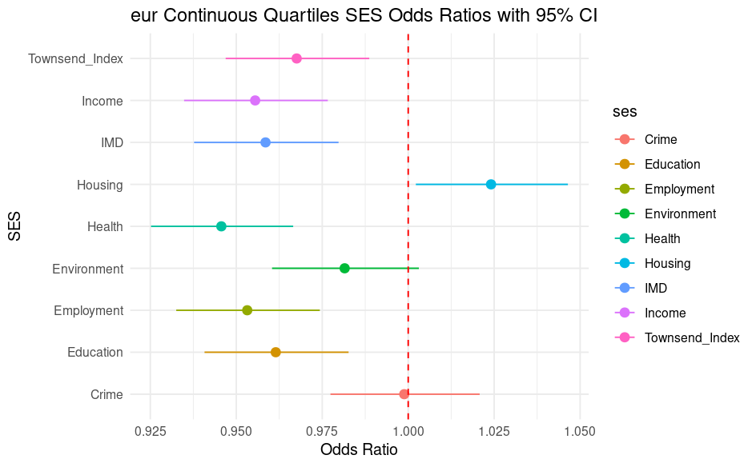

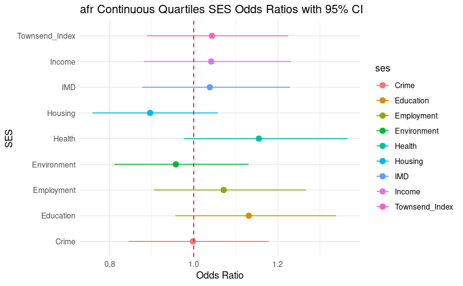

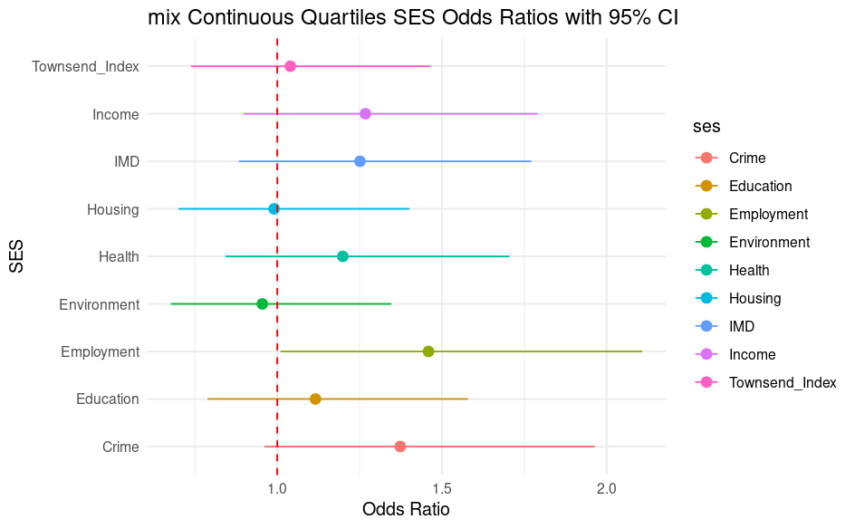

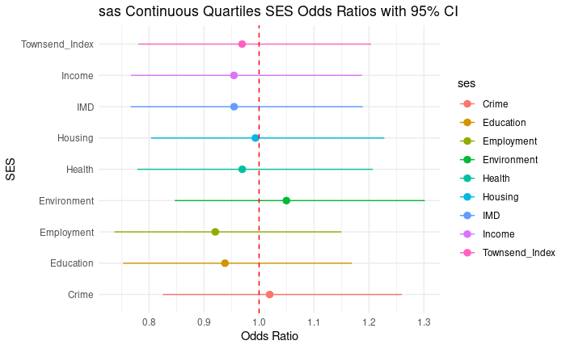

```r
# Edit this df to better plot
`%notin%` = Negate(`%in%`) # Quick helper function


# Loop through the different ancestries to plot

for (j in ances_exclude){
  plotting_df = summ_df %>%
    filter(ancestry == j) %>%
    filter(term %notin% c("(Intercept)", "age_assessment",                         "PSA_Screening"))


  # Create a plot for quartiles continuous
  p = plotting_df %>%
        ggplot(aes(x = OR, y = ses, xmin = low95, xmax = up95, color = ses)) +
        geom_pointrange() +
        geom_vline(xintercept = 1, linetype = "dashed", color = "red") +
        labs(x = "Odds Ratio", y = "SES") +
        ggtitle(paste0(j," Continuous Quartiles SES Odds Ratios with 95% CI")
                ) +
        theme_minimal()

  print(p)
}
```

#### Discrete Quartile model

I previously messed up my contintinuous quartile model. Aparently, thats not how you do it. If I was separating my data into quartiles, I should just keep it discrete and compare groups. I will include that code here. he fixed continuous model will be later

```r
keep_variables = c("data_df", "keep_variables", "ses_factors",
                   "ances","ances_exclude")
rm(list = ls()[!(ls() %in% keep_variables)])



# Create some dataframes to save the prevalence per ancestry
summ_df = tibble()

# I also want to loop through this per ancestry
for (j in ances_exclude){

  # Print ancestry to benchmark
  print(j)

  # Let's pull out the ancestry specific data and set list for models for this ancestry
  data_split = data_df %>% filter(Ances == j)
  model_results = list()

  # Now create a loop that models the variables of interest and then saves them to a list of models
  # Each loop will run a model for total, incidence, and prevalent cases
  for (i in ses_factors){

    # Make symbol for coding sake
      i = sym(i)

    # Create new data frame with quartile and rank data for each of the SES factors
    # I have 2 separate models for quartiles. One which is continuous and the other which is discrete
      temp_df = data_split %>% drop_na( !!i ) %>%
        mutate(Quartile_ = as.factor( ntile(!!i,4) )
               )

    # Repeat for discrete continuous
      model = logistic_reg() %>%
        fit(prostate_case ~ Quartile_ + age_assessment + PSA_Screening, data = temp_df)

      OR = tidy(model, exponentiate = T) %>%
        rename(OR = estimate) %>%
        mutate(low95 = exp(log(OR) - 1.96*std.error),
               up95 = exp(log(OR) + 1.96*std.error)) %>%
        select(-std.error, -statistic)

      model_results[[i]] <- OR


    # Benchmark that this set of model is complete
    print(i)
  }


  # Save the models
  results_df = list_rbind(model_results, names_to = "ses")

    # Then add to summary data_frame
    summ_df = results_df %>%
      mutate(ancestry = j) %>%
      rbind(summ_df, .)

}
```

```
[1] "eur"
IMD
Income
Employment
Health
Education
Housing
Crime
Environment
Townsend_Index
[1] "afr"
IMD
Income
Employment
Health
Education
Housing
Crime
Environment
Townsend_Index
[1] "mix"
IMD
Income
Employment
Health
Education
Housing
Crime
Environment
Townsend_Index
[1] "sas"
IMD
Income
Employment
Health
Education
Housing
Crime
Environment
Townsend_Index
```

```r
# And now export these models.
summ_df %>%
  write_csv( file = "/labs/jswitte/Projects/jjudd5/SES.PRS_Project/SES_Models/quartile_discrete_ses_models_2023.11.28.csv")
```

Now the plotting

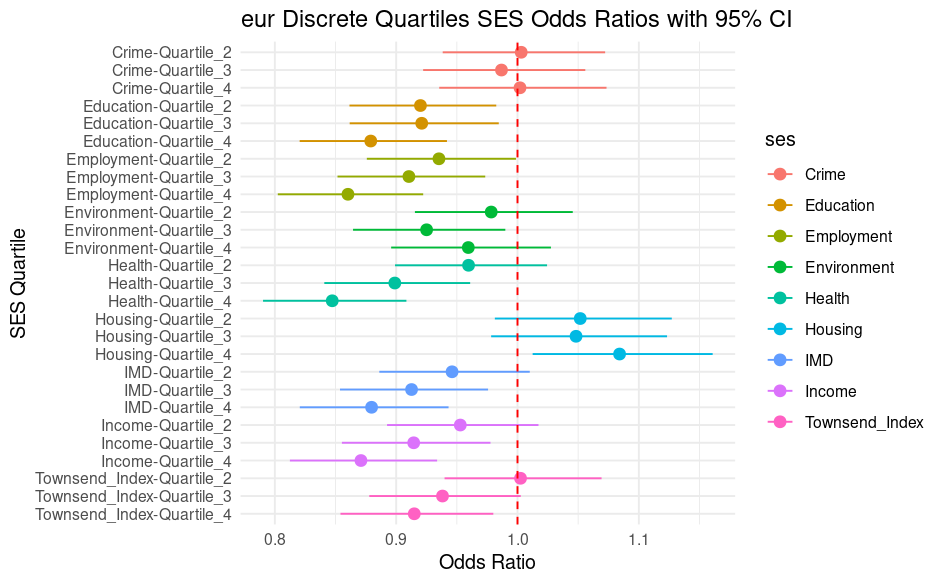

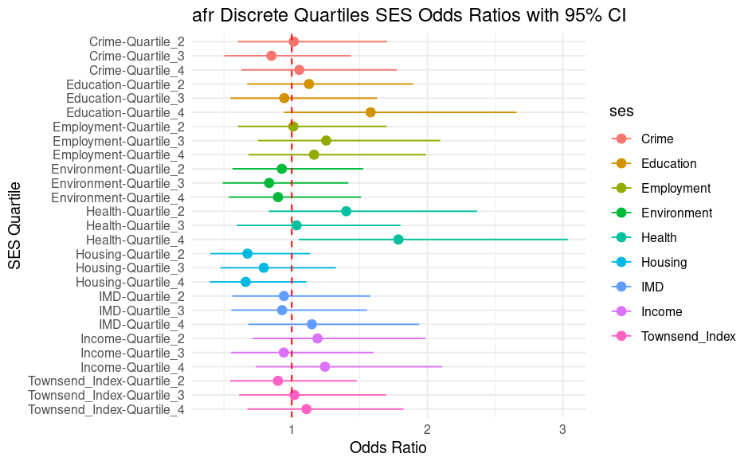

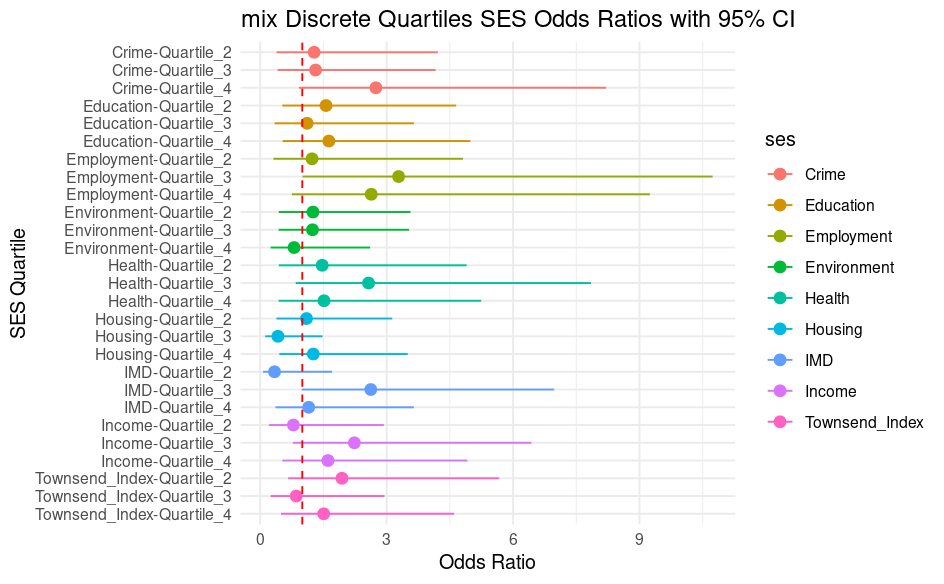

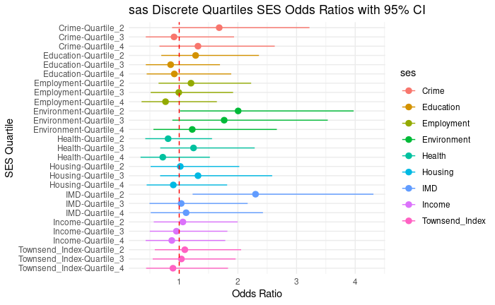

```r
# Edit this df to better plot
`%notin%` = Negate(`%in%`) # Quick helper function


for (j in ances_exclude){

  plotting_df = summ_df %>%
    filter(ancestry == j) %>%
    filter(term %notin% c("(Intercept)", "age_assessment", "PSA_Screening")) %>%
    mutate(SES_Quartile = as.factor(paste0(ses, "-",term))
           )


  # Create a plot for quartiles continuous
  p = plotting_df %>%
        ggplot(aes(x = OR,
                   y = SES_Quartile,
                   xmin = low95, xmax = up95, color = ses)) +
        geom_pointrange() +
        scale_y_discrete(limits = rev(levels(plotting_df$SES_Quartile))
                         ) +
        geom_vline(xintercept = 1, linetype = "dashed", color = "red") +
        labs(x = "Odds Ratio", y = "SES Quartile") +
        ggtitle(paste0(j, " Discrete Quartiles SES Odds Ratios with 95% CI")
                ) +
        theme_minimal()

  print(p)
}
```